# ReprodResearch1

CheccaAird

13 April 2016

Assignment 1

Loading and preprocessing the data

```r
#Load the activity CSV data
activityData <- read.table("activity.csv", sep = ",", header = TRUE)
```

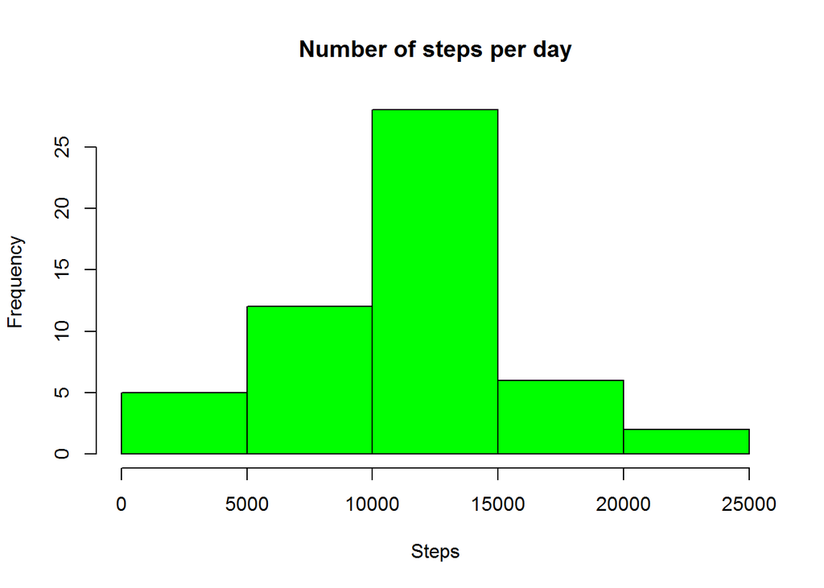

```r
# Total number of steps per day
stepsPerDay <- aggregate(steps ~ date, activityData, sum, na.rm= TRUE)

# Histogram of total number of steps taken per day
hist(stepsPerDay$steps,breaks=5 , main = "Number of steps per day", col="green", xlab="Steps")
```

```r
# Mean of steps, ignoring the missing values in the data set
stepsPerDayMean <- mean(activityData$steps, na.rm= TRUE)
stepsPerDayMean
```

```
## [1] 37.3826
```

```r
# Median of the total steps per day
stepsPerDayMedian <- median(activityData$steps, na.rm= TRUE)
stepsPerDayMedian
```

```
## [1] 0
```

What is the average daily activity pattern?

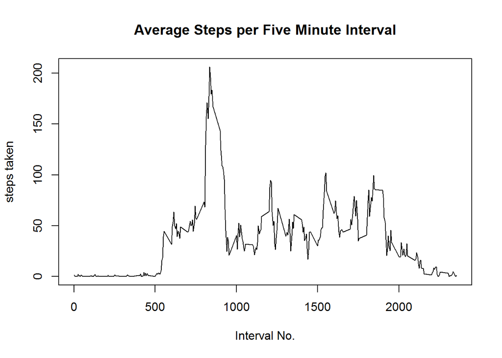

```r
# Time series plot of the 5 minute interval and the average number of steps taken, averaged across all days
stepsdata <- aggregate(steps ~ interval, activityData, mean, na.rm=TRUE)
plot(stepsdata$interval, stepsdata$steps, type="l", main="Average Steps per Five Minute Interval", xlab="Interval No.", ylab="steps taken")
```

```r
# The 5 minute interval with the maximum average number of steps
maxsteps <- max(stepsdata$steps)
maxsteps
```

```
## [1] 206.1698
```

Within the data there a number of days and intervals that are missing values. This can introduce bias into some of the calculations and summaries, which is why I have devised a strategy for filling in the missing values in the dataset.

```r
# The number of missing values in the dataset
nullValues <- sum(is.na(activityData$steps))
nullValues
```

```
## [1] 2304
```

My strategy is to use the mean values from the dataset to fill in the missing values. While this is a basic method, it will serve for the purpose of this assignment as it should have the least impact on the data summaries.

[figure not shown]

```r
# Fill in missing values
activityData$steps[is.na(activityData$steps)] <- mean(activityData$steps, na.rm = TRUE)
# Dataset with the missing data filled in
completeData <- aggregate(steps ~ date + interval, activityData, sum, na.rm= TRUE)
# Histogram of the total number of steps taken each day
hist(completeData$steps, breaks = 20, main = "Complete data- Total steps per day")
```

```r
# Mean and median  of total number of steps taken per day
completeDataMean <- mean(completeData$steps)
completeDataMean
```

```
## [1] 37.3826
```

```r
completeDataMedian <- median(completeData$steps)
completeDataMedian
```

```
## [1] 0
```

As I used the mean value for the missing values, there has been no impact on the median or the mean, which was my goal for filling in missing values.

Are there differences in activity patterns between weekdays and weekends?

The lattice library is needed for this exercise.

```r
library(lattice)
```

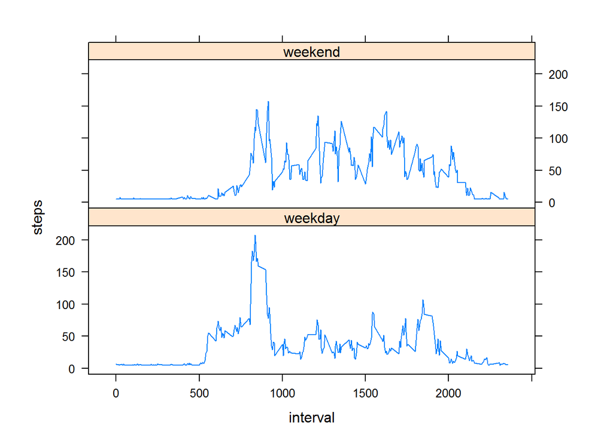

```r
# Factor variable in the dataset with two levels - "weekday" and "weekend" indicating whether a given date is a weekday or weekend day
completeData$date <- as.Date(completeData$date)
completeData$dayname <- weekdays(completeData$date)
completeData$weekend <- as.factor(ifelse(completeData$dayname == "Saturday" | completeData$dayname == "Sunday", "weekend", "weekday"))
# Panel plot contain 2 times series plots of the 5 minute interval and the average number of steps
latticeData <- aggregate(steps ~interval + weekend, completeData, mean)
xyplot(steps ~ interval | factor(weekend), data=latticeData, type= "l", aspect = 1/3)
```